# Group H - Assignment Block B

J. Al Sayed Kassem, B. Hadman, N. Pinat, M. Secci, F. Tomada

2026-10-27

## CS - Chapter 1

### Ex 1.1

Exponential random variable, $X \ge 0$, has p.d.f. $f(x) = \lambda e^{-\lambda x}$.

Find the c.d.f. and the quantile function for $X$.

Find $\Pr(X \le a)$ and the median of $X$.

Find the mean and variance of $X$.

Solution

Cumulative Distribution Function (c.d.f.) and Quantile: The cumulative distribution function $F(x)$ is obtained by integrating the probability density function from $0$ to $x$:

$$F(x) = P(X \le x) = \int_{0}^{x} \lambda
e^{-\lambda t} dt = \left[ -e^{-\lambda t} \right]_{0}^{x} = 1 -
e^{-\lambda x} \quad (\text{for } x \ge 0)$$

To find the quantile function $F^{-1}(p)$, we set $F(x)$ equal to $p$ and solve for $x$:

$$1 - e^{-\lambda x} = p \implies
e^{-\lambda x} = 1 - p \implies -\lambda x = \ln(1-p)$$

From which we obtain the quantile function:

$$Q(p) = -\frac{\ln(1-p)}{\lambda} \quad
\text{for } p \in (0,1)$$

Probability $\Pr(X \le a)$ and Median:

The probability that $X$ is less than or equal to a constant $a \ge 0$ is given directly by the c.d.f.:

$$\Pr(X \le a) = F(a) = 1 - e^{-\lambda
a}$$

The median corresponds to the quantile of order $p = 0.5$:

$$\text{Median} = Q(0.5) = -\frac{\ln(1 -
0.5)}{\lambda} = -\frac{\ln(0.5)}{\lambda} =
\frac{\ln(2)}{\lambda}$$

Mean and Variance of $X$:

Mean $E[X]$: Integrating by parts:

$$E[X] = \int_{0}^{\infty} x \lambda
e^{-\lambda x} dx = \left[ -x e^{-\lambda x} \right]_{0}^{\infty} +
\int_{0}^{\infty} e^{-\lambda x} dx = 0 + \left[ -\frac{e^{-\lambda
x}}{\lambda} \right]_{0}^{\infty} = \frac{1}{\lambda}$$

Variance $\text{Var}(X)$: First, we calculate the second moment $E[X^2]$ (via integration by parts):

$$E[X^2] = \int_{0}^{\infty} x^2 \lambda
e^{-\lambda x} dx = \frac{2}{\lambda^2}$$

Using the fundamental relationship of variance $\text{Var}(X) = E[X^2] - (E[X])^2$:

$$\text{Var}(X) = \frac{2}{\lambda^2} -
\left(\frac{1}{\lambda}\right)^2 = \frac{2 - 1}{\lambda^2} =
\frac{1}{\lambda^2}$$

### Ex 1.6

Let $X$ and $Y$ be random variables with $\text{Var}(X) = \sigma_x^2$, $\text{Var}(Y) = \sigma_y^2$, and $\text{Cov}(X,Y) = \sigma_{xy}$. Find $\text{Var}(X+Y)$ and $\text{Var}(X-Y)$.

Solution

Recalling the properties of variance for the sum of two random variables (not necessarily independent):

Variance of the sum $\text{Var}(X + Y)$:

$$\text{Var}(X + Y) = \text{Var}(X) +
\text{Var}(Y) + 2\text{Cov}(X,Y) = \sigma_x^2 + \sigma_y^2 +
2\sigma_{xy}$$

Variance of the difference $\text{Var}(X - Y)$:

$$\text{Var}(X - Y) = \text{Var}(X) +
\text{Var}(-Y) + 2\text{Cov}(X, -Y) = \sigma_x^2 + \sigma_y^2 -
2\sigma_{xy}$$

## CS - Chapter 3

### Ex 3.5

```r
# Setup
set.seed(0)
n <- 1000
A <- matrix(runif(n*n), n, n)
x.true <- runif(n)
y <- A %*% x.true

# B
tempo_b <- system.time({
  A_inv <- solve(A)
  x1 <- A_inv %*% y
})

print("Time with explicit inverse:")
```

```
## [1] "Time with explicit inverse:"
```

```r
print(tempo_b)
```

```
##    user  system elapsed
##   0.440   0.035   0.040
```

```r
# C
tempo_c <- system.time({
  x2 <- solve(A, y)
})

error1 <- mean(abs(x1-x.true))
error2 <- mean(abs(x2-x.true))

print("Time with direct solution:")
```

```
## [1] "Time with direct solution:"
```

```r
print(tempo_c)
```

```
##    user  system elapsed
##   0.131   0.000   0.011
```

```r
error1
```

```
## [1] 2.67414e-11
```

```r
error2
```

```
## [1] 8.227913e-13
```

### Ex 3.6

```r
# ==============================================================================
# Function for the Empirical C.D.F.
# ==============================================================================
# Definition based on the formula: F_hat(x) = #{x_i < x} / n
#
# Arguments:
#   - x        : numeric unordered vector of observations
#   - plot.cdf : boolean (TRUE/FALSE). If TRUE, generates the step plot.
# ==============================================================================

compute_ecdf <- function(x, plot.cdf = FALSE) {
  # Total number of observations
  n <- length(x)

  if (n == 0) {
    stop("The input vector is empty.")
  }

  # a. Calculates the empirical c.d.f. for each element, preserving the original order
  # For each element x[i], counts how many elements in the vector are strictly smaller (<)
  ecdf_values <- sapply(x, function(xi) {
    sum(x < xi) / n
  })

  if (plot.cdf) {
    x_ordinato <- sort(x)
    y_ordinato <- (0:(n - 1)) / n

    plot(x_ordinato, y_ordinato, type = "s", lwd = 2, col = "blue",
         main = "Empirical Cumulative Distribution Function (E.C.D.F.)",
         xlab = "x", ylab = expression(hat(F)(x)))
    grid()
  }

  return(ecdf_values)
}


set.seed(42)

campione <- rnorm(15)

print("Original vector of observations:")
```

```
## [1] "Original vector of observations:"
```

```r
print(campione)
```

```
##  [1]  1.37095845 -0.56469817  0.36312841  0.63286260  0.40426832 -0.10612452
##  [7]  1.51152200 -0.09465904  2.01842371 -0.06271410  1.30486965  2.28664539
## [13] -1.38886070 -0.27878877 -0.13332134
```

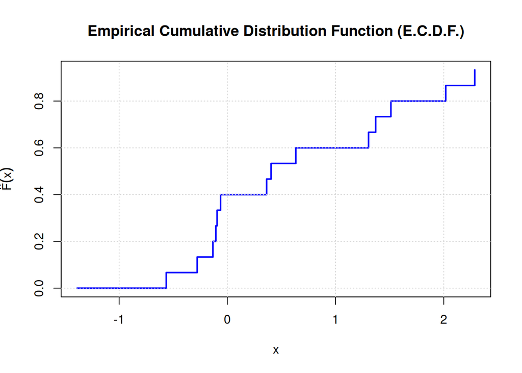

```r
risultati_ecdf <- compute_ecdf(campione, plot.cdf = TRUE)
```

```r
print("Values of the empirical c.d.f. (in the order corresponding to the original vector):")
```

```
## [1] "Values of the empirical c.d.f. (in the order corresponding to the original vector):"
```

```r
print(risultati_ecdf)
```

```
##  [1] 0.73333333 0.06666667 0.46666667 0.60000000 0.53333333 0.26666667
##  [7] 0.80000000 0.33333333 0.86666667 0.40000000 0.66666667 0.93333333
## [13] 0.00000000 0.13333333 0.20000000
```

## FSDS - Chapter 2

### Ex 2.8

Each time a person shops at a grocery store, the event of catching a cold or some other virus from another shopper is independent from visit to visit and has a constant probability over the year, equal to 0.01.

1. **In 100 trips to this store over the course of a year, the probability of catching a virus while shopping there is $100(0.01) = 1.0$. What is wrong with this reasoning?**
2. **Find the correct probability in (a).**

**Solution**

1. **Analysis of part (a):** The reasoning is incorrect because it treats probabilities as linear cumulative quantities ($100 \times 0.01 = 1.0$). This erroneously assumes that the probabilities of independent events add up linearly and that the event becomes an absolute certainty (probability = 1). In reality, for repeated independent trials, the probability does not add up, but is calculated through the complementary event.
2. **Calculation of the correct probability (b):**
   - **Probability of not contracting the virus in a single trip:**
     $$1 - 0.01 =
     0.99$$
   - **Probability of never contracting the virus in all 100 trips** (since they are independent events, the probabilities are multiplied):
     $$P(\text{never}) = (0.99)^{100}
     \approx 0.366$$
   - **Probability of contracting the virus at least once** (complementary event):
     $$P(X \ge 1) = 1 -
     (0.99)^{100} \approx 1 - 0.366 = 0.634 \quad (63.4\%)$$

### Ex 2.16

1. **In the first week, the observations from Sunday to Saturday are 10, 8, 14, 7, 21, 44, 60. Do you think that the Poisson distribution might describe the random variability of this phenomenon adequately? Why or why not?**
2. **Would you expect the Poisson distribution to better describe, or more poorly describe, the number of weekly admissions to the hospital for a rare disease? Why?**

**Solution**

1. **Analysis of part (a):** **No**, the Poisson distribution is not suitable to describe this phenomenon for two main reasons:
   - **Overdispersion:** The Poisson distribution requires mean and variance to be equal ($\mu = \sigma^2$). In this sample the variance is enormously higher than the mean due to the high peaks reached in the last few days (up to 60).
   - **Lack of stationarity:** The average rate $\lambda$ is not constant over time, but shows strong variability and an increasing trend towards the end of the week.
2. **Analysis of part (b):** **Yes**, we would expect the Poisson distribution to adequately describe the number of weekly hospital admissions for a rare disease.
   - **Rationale:** In this case, admissions satisfy the fundamental hypotheses of the Poisson process: events are rare, occur independently, and the average admission rate ($\lambda$) over time can be considered reasonably constant, without extreme systematic fluctuations as in the previous case.

### Ex 2.21

**Question:** Plot the Gamma distribution with shape parameter k = 3 and scale parameters 0.5, 1, 2, 3, 4, 5. What is the effect of increasing the scale parameter?

**Solution:**

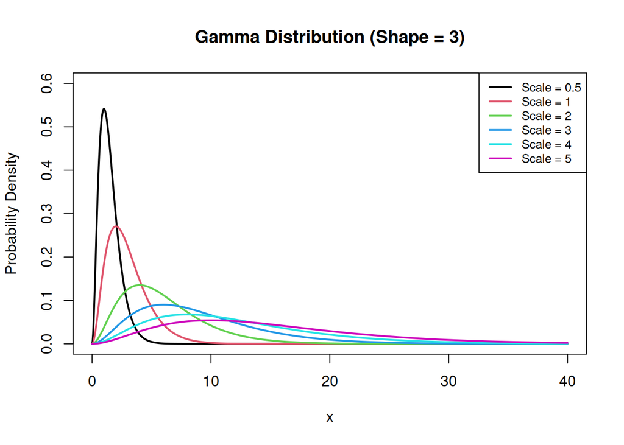

```r
# Set the shape and scale parameters
k <- 3
scales <- c(0.5, 1, 2, 3, 4, 5)

# Create x values
x <- seq(0, 40, length.out = 1000)

# Plot the first Gamma distribution
plot(x, dgamma(x, shape = k, scale = scales[1]),
     type = "l", col = 1, lwd = 2,
     ylim = c(0, 0.6),
     xlab = "x", ylab = "Probability Density",
     main = "Gamma Distribution (Shape = 3)")

# Add the other distributions
for (i in 2:length(scales)) {
  lines(x, dgamma(x, shape = k, scale = scales[i]),
        col = i, lwd = 2)
}

# Add the legend
legend("topright",
       legend = paste("Scale =", scales),
       col = 1:6, lwd = 2, cex = 0.8)
```

**Interpretation:**

Increasing the scale parameter makes the Gamma distribution more spread out and shifts it toward larger values.

The mean and variance of a Gamma distribution are:

$$E(X) = k\theta$$

$$Var(X) = k\theta^2$$

Since the shape parameter k = 3 remains fixed, increasing the scale parameter increases both the mean and the variance.

The density curve becomes wider and flatter, while its total area remains equal to 1.

### Ex 2.26

**Question:** Refer to Table 2.4, cross-classifying happiness with family income.

1. Find and interpret the correlation using scores:
2. (1, 2, 3) for each variable;
2. (1, 2, 3) for income and (1, 4, 5) for happiness.
2. Construct the joint distribution with the same marginal distributions, assuming independence.

**Solution (a): Correlation**

```r
# Joint probability distribution from Table 2.4
P <- matrix(c(0.080, 0.198, 0.079,
              0.043, 0.254, 0.143,
              0.017, 0.105, 0.081),
            nrow = 3, byrow = TRUE)

# Marginal probabilities
px <- rowSums(P)
py <- colSums(P)

# Income scores
x <- c(1, 2, 3)

# Function to calculate correlation
joint_cor <- function(x, y, P) {
  px <- rowSums(P)
  py <- colSums(P)

  EX <- sum(x * px)
  EY <- sum(y * py)

  EXY <- sum(outer(x, y) * P)

  covXY <- EXY - EX * EY

  varX <- sum(x^2 * px) - EX^2
  varY <- sum(y^2 * py) - EY^2

  covXY / sqrt(varX * varY)
}

# Scoring system (i)
cor1 <- joint_cor(x, c(1, 2, 3), P)

# Scoring system (ii)
cor2 <- joint_cor(x, c(1, 4, 5), P)

round(c(System_i = cor1, System_ii = cor2), 4)
```

```
##  System_i System_ii
##    0.1907    0.1898
```

**Interpretation:**

For scoring system (i), the correlation is approximately 0.1907. For scoring system (ii), it is approximately 0.1898.

Both values indicate a weak positive association between family income and happiness. The small difference shows that the numerical scores assigned to ordinal categories can affect the correlation.

**Solution (b): Independence**

```r
# Joint probabilities under independence
P_independent <- outer(px, py)

rownames(P_independent) <- c("Below average",
                             "Average",
                             "Above average")

colnames(P_independent) <- c("Not too happy",
                             "Pretty happy",
                             "Very happy")

round(P_independent, 6)
```

```
##               Not too happy Pretty happy Very happy
## Below average       0.04998     0.198849   0.108171
## Average             0.06160     0.245080   0.133320
## Above average       0.02842     0.113071   0.061509
```

```r
# Check that the marginals are unchanged
rowSums(P_independent)
```

```
## Below average       Average Above average
##         0.357         0.440         0.203
```

```r
colSums(P_independent)
```

```
## Not too happy  Pretty happy    Very happy
##         0.140         0.557         0.303
```

**Interpretation:**

The independent joint distribution is obtained by multiplying the corresponding marginal probabilities:

$$P(X=x,Y=y)=P(X=x)P(Y=y).$$

The resulting distribution preserves the original marginal probabilities while making family income and happiness independent.

### Ex 2.52

**Solution (a)**

Let $Y \sim N(\mu,\sigma^2)$ and define the standard normal random variable

$$Z=\frac{Y-\mu}{\sigma}.$$

By the definition of the cumulative distribution function,

$$F(y)=P(Y\leq y).$$

Since $\sigma>0$, standardizing gives

$$F(y)=P\left(\frac{Y-\mu}{\sigma}
\leq\frac{y-\mu}{\sigma}\right).$$

Therefore,

$$\boxed{F(y)=\Phi\left(\frac{y-\mu}{\sigma}\right)}.$$

**Solution (b)**

The probability density function is the derivative of the cumulative distribution function:

$$f(y)=\frac{d}{dy}F(y).$$

Using the result from part (a) and applying the chain rule,

$$f(y)=\phi\left(\frac{y-\mu}{\sigma}\right)
\frac{d}{dy}\left(\frac{y-\mu}{\sigma}\right).$$

Hence,

$$\boxed{f(y)=\frac{1}{\sigma}
\phi\left(\frac{y-\mu}{\sigma}\right)}.$$

From Equation (2.9), the standard normal density is

$$\phi(z)=\frac{1}{\sqrt{2\pi}}e^{-z^2/2}.$$

Substituting gives

$$\boxed{
f(y)=\frac{1}{\sigma\sqrt{2\pi}}
e^{-\frac{(y-\mu)^2}{2\sigma^2}}
}.$$

This is Equation (2.8), the probability density function of a normal distribution.

### Ex 2.53

**Solution**

Let $Y \sim N(0,1)$ and define $X=\Phi(Y)$, where $\Phi$ is the standard normal cumulative distribution function.

By the probability integral transformation, if $F$ is the continuous CDF of a random variable $Y$, then $F(Y)$ follows a Uniform(0,1) distribution.

Therefore,

$$\boxed{X=\Phi(Y)\sim \mathrm{Uniform}(0,1)}.$$

We verify this result by generating one million standard normal random values and transforming them using the standard normal CDF.

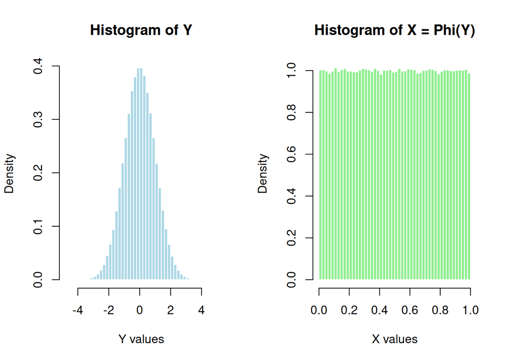

```r
# Generate one million standard normal observations
set.seed(123)
y <- rnorm(1000000, mean = 0, sd = 1)

# Apply the standard normal CDF
x <- pnorm(y)

# Display both histograms side by side
par(mfrow = c(1, 2))

hist(y,
     breaks = 60,
     probability = TRUE,
     main = "Histogram of Y",
     xlab = "Y values",
     col = "lightblue",
     border = "white")

hist(x,
     breaks = 60,
     probability = TRUE,
     main = "Histogram of X = Phi(Y)",
     xlab = "X values",
     col = "lightgreen",
     border = "white")
```

```r
# Restore the default plotting layout
par(mfrow = c(1, 1))
```

**Interpretation**

The histogram of Y is approximately bell-shaped, as expected for a standard normal distribution.

The histogram of X is approximately flat over the interval (0,1), confirming that X follows a Uniform(0,1) distribution.

### Ex 2.70

**Solution (a): Uniform distribution**

For alpha = beta = 1, the beta density becomes

$$f(y;1,1)=
\frac{\Gamma(2)}{\Gamma(1)\Gamma(1)}
y^0(1-y)^0=1.$$

Thus, for $0\leq y\leq1$, this is the density of a Uniform(0,1) distribution.

**Solution (b): Expected value**

By definition,

$$E(Y)=\int_0^1 yf(y)\,dy.$$

Substituting the beta density,

$$E(Y)=
\frac{\Gamma(\alpha+\beta)}
{\Gamma(\alpha)\Gamma(\beta)}
\int_0^1 y^\alpha(1-y)^{\beta-1}\,dy.$$

Using the beta-gamma identity and $\Gamma(t+1)=t\Gamma(t)$,

$$E(Y)=
\frac{\Gamma(\alpha+\beta)\Gamma(\alpha+1)}
{\Gamma(\alpha)\Gamma(\alpha+\beta+1)}
=\boxed{\frac{\alpha}{\alpha+\beta}}.$$

**Solution (c): Second moment and variance**

Similarly,

$$E(Y^2)=
\frac{\Gamma(\alpha+\beta)\Gamma(\alpha+2)}
{\Gamma(\alpha)\Gamma(\alpha+\beta+2)}
=\boxed{
\frac{\alpha(\alpha+1)}
{(\alpha+\beta)(\alpha+\beta+1)}
}.$$

Using $Var(Y)=E(Y^2)-[E(Y)]^2$,

$$Var(Y)=
\frac{\alpha(\alpha+1)}
{(\alpha+\beta)(\alpha+\beta+1)}
-\frac{\alpha^2}{(\alpha+\beta)^2}.$$

Simplifying,

$$\boxed{
Var(Y)=\frac{\alpha\beta}
{(\alpha+\beta)^2(\alpha+\beta+1)}
}.$$

Since $\mu=\alpha/(\alpha+\beta)$,

$$\boxed{
Var(Y)=\frac{\mu(1-\mu)}{\alpha+\beta+1}
}.$$

For fixed $\alpha+\beta$, the variance is largest when $\mu=0.5$ and decreases as $\mu$ approaches 0 or 1.

**Solution (d): Beta density plots**

We use the R function `dbeta()` to plot beta probability density functions for different parameter combinations.

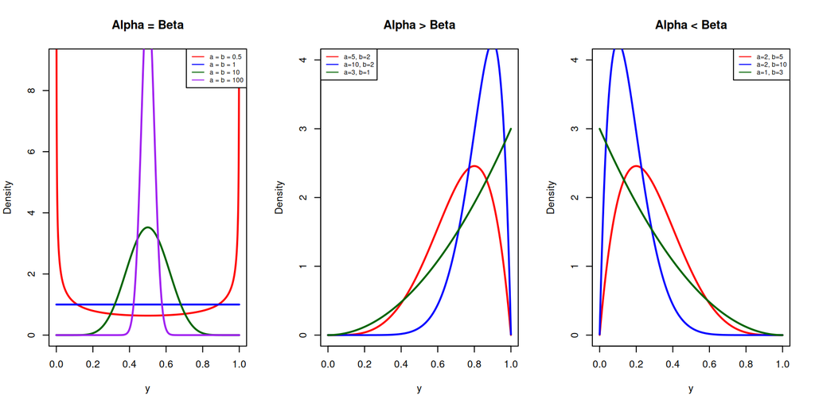

```r
# Values strictly inside (0,1)
y <- seq(0.0001, 0.9999, length.out = 2000)

# Three panels
par(mfrow = c(1, 3))

# (i) Equal parameters
params <- c(0.5, 1, 10, 100)
cols <- c("red", "blue", "darkgreen", "purple")

plot(y, dbeta(y, 0.5, 0.5),
     type = "l", col = cols[1], lwd = 2,
     ylim = c(0, 9),
     main = "Alpha = Beta",
     xlab = "y", ylab = "Density")

for (i in 2:4) {
  lines(y, dbeta(y, params[i], params[i]),
        col = cols[i], lwd = 2)
}

legend("topright",
       legend = paste("a = b =", params),
       col = cols, lty = 1, cex = 0.65)

# (ii) Alpha greater than Beta
plot(y, dbeta(y, 5, 2),
     type = "l", col = "red", lwd = 2,
     ylim = c(0, 4),
     main = "Alpha > Beta",
     xlab = "y", ylab = "Density")

lines(y, dbeta(y, 10, 2),
      col = "blue", lwd = 2)
lines(y, dbeta(y, 3, 1),
      col = "darkgreen", lwd = 2)

legend("topleft",
       legend = c("a=5, b=2", "a=10, b=2",
                  "a=3, b=1"),
       col = c("red", "blue", "darkgreen"),
       lty = 1, cex = 0.65)

# (iii) Alpha less than Beta
plot(y, dbeta(y, 2, 5),
     type = "l", col = "red", lwd = 2,
     ylim = c(0, 4),
     main = "Alpha < Beta",
     xlab = "y", ylab = "Density")

lines(y, dbeta(y, 2, 10),
      col = "blue", lwd = 2)
lines(y, dbeta(y, 1, 3),
      col = "darkgreen", lwd = 2)

legend("topright",
       legend = c("a=2, b=5", "a=2, b=10",
                  "a=1, b=3"),
       col = c("red", "blue", "darkgreen"),
       lty = 1, cex = 0.65)
```

```r
par(mfrow = c(1, 1))
```

**Interpretation**

When alpha = beta, the distribution is symmetric. For alpha = beta = 0.5, it is U-shaped. For alpha = beta = 1, it is uniform. For alpha = beta = 10 or 100, it becomes increasingly concentrated around 0.5.

When alpha > beta, the distribution is concentrated toward larger values of y.

When alpha < beta, the distribution is concentrated toward smaller values of y.

The total alpha + beta controls concentration, while their relative sizes determine the mean and the direction of asymmetry.

## FSDS - Chapter 3

### Ex 3.2

*In an exit poll of 1648 voters in the 2020 Senatorial election in Arizona, 51.5% said they voted for Mark Kelly and 48.5% said they voted for Martha McSally.*

*(a) Suppose that actually 50% of the population voted for Kelly. If this exit poll had the properties of a simple random sample, find the standard error of the sample proportion voting for him.*

*(b) Under the 50% presumption, are the results of the exit poll surprising? Why? Would you be willing to predict the election outcome? Explain by (i) conducting a simulation; (ii) using the value found in (a) for the standard error.*

**Solution**

```r
n     <- 1648   # poll size
p_obs <- 0.515  # observed proportion for Kelly
p0    <- 0.5    # presumed population proportion (H0)
```

**(a)** Under $\pi = 0.5$, the number of votes for Kelly is $Y \sim \text{Bin}(n, \pi)$ and the sample proportion $\hat\pi = Y/n$ has standard error

$$\sigma_{\hat\pi} =
\sqrt{\frac{\pi(1-\pi)}{n}}.$$

```r
se <- sqrt(p0 * (1 - p0) / n)
se
```

```
## [1] 0.01231662
```

**(b)(i)** We simulate $10^6$ exit polls of size $n$ from a population where $\pi = 0.5$. `rbinom` returns counts, so we divide by $n$ to get proportions.

```r
set.seed(0)
B <- 1e6
results <- rbinom(B, n, p0) / n
mean(results); sd(results)
```

```
## [1] 0.5000101
```

```
## [1] 0.01230478
```

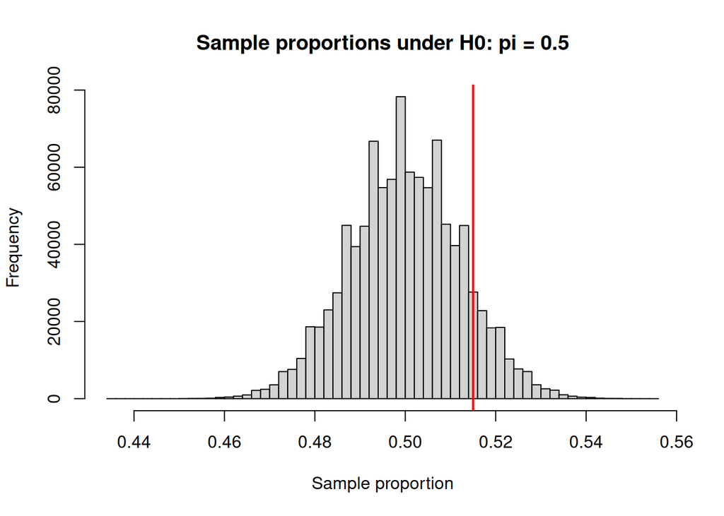

```r
hist(results, breaks = 50, main = "Sample proportions under H0: pi = 0.5",
     xlab = "Sample proportion")
abline(v = p_obs, col = "red", lwd = 2)
```

```r
# share of simulated polls with at least 51.5% for Kelly
mean(results >= p_obs)
```

```
## [1] 0.113649
```

The simulated standard deviation (0.01230) matches the standard error from (a) (0.01232), as expected. About 11.4% of the simulated polls give 51.5% or more for Kelly even though the race is exactly 50/50. By symmetry, about twice as many fall at least that far from 0.5 in either direction.

**(b)(ii)** Using the standard error from (a), we measure how many standard errors the observed proportion lies from 0.5:

```r
z <- (p_obs - p0) / se
z
```

```
## [1] 1.217867
```

```r
1 - pnorm(z)   # normal approximation, compare with the simulation
```

```
## [1] 0.1116373
```

So 0.515 is only 1.22 standard errors above 0.5. This is well within the range of about $\pm 3$ standard errors where almost all sample proportions fall, and the normal approximation gives nearly the same tail probability as the simulation.

**Conclusion.** The poll result is not surprising under the 50% presumption: a tied race produces a poll this far from 50% quite often. So we would not be willing to predict that Kelly wins based on this poll alone. This is unlike the California exit poll in Section 3.1.1, where 65.5% was about 15 standard errors from 0.5. Also, real exit polls are not simple random samples, so the true uncertainty is likely larger than this standard error suggests.

### Ex 3.16

*According to the U.S. Census Bureau, the number of people in a household has a mean of 2.6 and a standard deviation of 1.5. Suppose the Census Bureau instead had estimated this mean using a random sample of 225 homes, and that sample had a mean of 2.4 and standard deviation of 1.4.*

*Describe the center and spread of the (a) population distribution, (b) sample data distribution, (c) sampling distribution of the sample mean for 225 homes.*

**Solution**

```r
mu    <- 2.6   # population mean (Census)
sigma <- 1.5   # population SD (Census)
n     <- 225   # sample size
ybar  <- 2.4   # observed sample mean
s     <- 1.4   # observed sample SD
```

**(a) Population distribution.** This is the distribution of household size over all U.S. homes. Its center is $\mu = 2.6$ and its spread is $\sigma = 1.5$. Household size is a positive count with a long right tail (many homes with 1–2 people, a few very large ones), so the distribution is skewed right, not normal.

**(b) Sample data distribution.** This is the distribution of the 225 observed household sizes. Its center is $\bar y = 2.4$ and its spread is $s = 1.4$. These are close to, but not equal to, $\mu$ and $\sigma$: the sample is one random draw, so its mean and standard deviation change from sample to sample. Its shape should look like the population’s (skewed right).

**(c) Sampling distribution of $\bar Y$.** This is the distribution of the sample mean over all possible random samples of 225 homes. Its center is $E(\bar Y) = \mu = 2.6$ and its spread is the standard error

$$\sigma_{\bar Y} = \frac{\sigma}{\sqrt
n} = \frac{1.5}{\sqrt{225}} = 0.1.$$

In practice we would only have the sample, so we would estimate it with $s/\sqrt n$:

```r
center_c  <- mu               # E(Ybar)
se_theory <- sigma / sqrt(n)  # true standard error
se_hat    <- s / sqrt(n)      # standard error estimated from the sample
center_c; se_theory; se_hat
```

```
## [1] 2.6
```

```
## [1] 0.1
```

```
## [1] 0.09333333
```

The estimate (0.093) is close to the true value (0.1). Because $n = 225$ is large, the Central Limit Theorem says $\bar Y$ is approximately normal, even though the population is skewed. The standard error is much smaller than $\sigma$ because averaging 225 homes cancels most of the variation between single households.

**How unusual is $\bar y = 2.4$?**

```r
z <- (ybar - mu) / se_theory
z
```

```
## [1] -2
```

```r
2 * pnorm(-abs(z))   # two-sided probability
```

```
## [1] 0.04550026
```

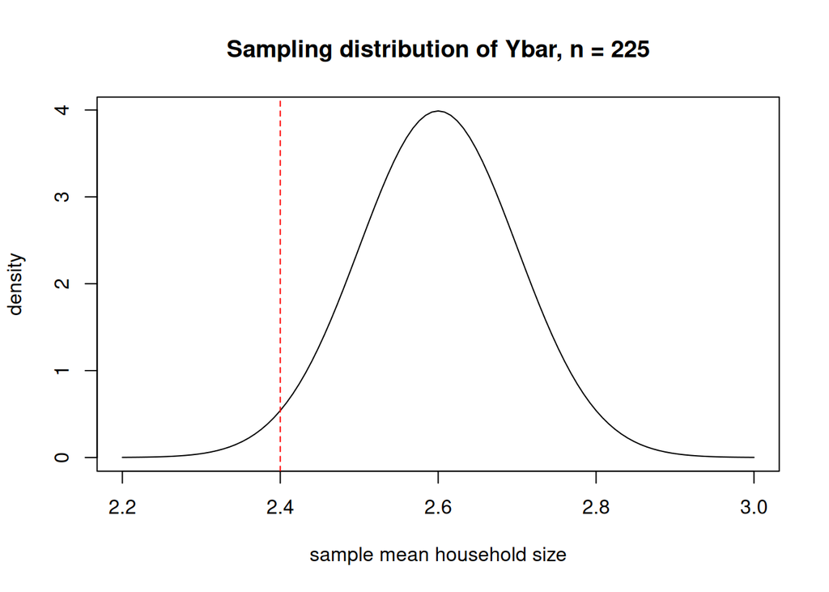

```r
curve(dnorm(x, center_c, se_theory), from = 2.2, to = 3.0,
      main = "Sampling distribution of Ybar, n = 225",
      xlab = "sample mean household size", ylab = "density")
abline(v = ybar, col = "red", lty = 2)   # observed ybar
```

The observed mean is 2 standard errors below $\mu$. A sample mean at least this far from 2.6 happens only about 4.6% of the time, so 2.4 is somewhat unusual (but possible) if the true mean is 2.6.

## FSDS - Chapter 4

### Ex 4.8

*To estimate the proportion of traffic deaths in California last year that were alcohol related, determine the necessary sample size for the estimate to be accurate to within 0.04 with probability 0.90. Based on results of studies reported by the National Highway Traffic Safety Administration (www.nhtsa.gov), we expect the proportion to be about 0.30.*

**Solution**

```r
p <- 0.30
error <- 0.04
confidence <- 0.90

z <- qnorm(1 - (1 - confidence) / 2)

s_required <- ceiling(z^2 * p * (1 - p) / error^2)

#A sample size of 356 is required
# Formatted output
cat("\nEXERCISE 4.8 - REQUIRED SAMPLE SIZE\n")
cat("----------------------------------------\n")
cat("Confidence level: 90%\n")
cat("Expected proportion: 0.30\n")
cat("Margin of error: 0.04\n\n")

cat(sprintf("Required sample size: %.0f\n", s_required))
```

```
##
## EXERCISE 4.8 - REQUIRED SAMPLE SIZE
## ----------------------------------------
## Confidence level: 90%
## Expected proportion: 0.30
## Margin of error: 0.04
##
## Required sample size: 356
```

### Ex 4.14

*Using the Students data file, for the corresponding population, construct a 95% confidence interval (a) for the mean weekly number of hours spent watching TV; (b) to compare females and males on the mean weekly number of hours spent watching TV. In each case, state assumptions, including the practical importance of each, and interpret results.*

**Solution**

```r
#Import full data set from textbook
#gender: 0=male, 1=female

students <- read.table(header=TRUE, text="

subject gender age hsgpa cogpa dhome dres tv sport news aids veg affil ideol relig abor affirm life
1     0  32  2.2  3.5  0     5.0  3   5  0   0  0  2  6  2  0  0  1
2     1  23  2.1  3.5  1200  0.3  15  7  5   6  1  1  2  1  1  1  3
3     1  27  3.3  3.0  1300  1.5  0   4  3   0  1  1  2  2  1  1  3
4     1  35  3.5  3.2  1500  8    5   5  6   3  0  3  4  1  1  1  2
5     0  23  3.1  3.5  1600  10   6   6  3   0  0  3  1  0  1  0  2
6     0  39  3.5  3.5  350   3    4   5  7   0  1  1  2  1  1  1  3
7     0  24  3.6  3.7   0    .2   5  12  4   2  0  3  2  1  1  1  1
8     1  31  3.0  3.0  5000  1.5  5   3  3   1  0  3  2  1  1  1  1
9     0  34  3.0  3.0  5000  2    7   5  3   0  0  3  1  1  1  1  3
10    0  28  4.0  3.1  900   2    1   1  2   1  1  3  3  0  0  1  1
11    0  23  2.3  2.6  253   1.5  10 15  1   1  0  2  5  1  0  1  1
12    1  27  3.5  3.6  190   3    14  3  7   0  0  1  2  1  1  1  3
13    0  36  3.3  3.5  245   1.5  6  15 12   5  0  1  1  1  1  1  1
14    0  28  3.2  3.2  500   6    3  10  1   2  0  3  4  1  1  0  1
15    1  28  3.0  3.5  3500  1    4   3  1   0  0  1  1  0  1  1  1
16    1  25  3.8  3.3  210   10   7   6  1   0  1  3  2  3  1  1  1
17    1  41  4.0  3.0  1000  15   6   7  3  10  0  3  3  3  0  0  1
18    0  50  3.8  3.8  0     3    5   9  6  10  0  1  2  0  1  0  2
19    0  71  4.0  3.5  5000  3    6  12  2   2  0  3  2  0  1  0  2
20    1  28  3.0  3.8  120   1    25  0  0   2  1  1  1  1  1  1  1
21    1  26  3.7  3.7  8000  8    4   4  4   1  0  3  4  1  1  1  1
22    1  27  4.0  3.7  2     2.5  4   2  7   0  0  3  2  1  1  1  1
23    0  31  2.7  3.5  1700  5    7   7  2   0  0  2  7  3  0  0  1
24    1  23  3.7  3.7  2     2    7   4  2   0  0  3  4  0  1  1  1
25    0  23  3.2  3.8  450   4    0   7  7   3  0  3  1  0  1  1  1
26    1  44  3.0  3.0  0     2    2   3  2   3  1  3  3  2  1  1  1
27    0  26  3.7  3.0  1000  3    8   2  7   0  0  1  2  1  1  1  3
28    1  31  3.7  3.8  850  10    10  3  7   0  0  2  5  2  1  0  1
29    0  24  3.3  3.1  420   2    10  6  5   0  0  1  4  1  1  1  3
30    1  26  3.3  3.3  1200  .75  10  0  3   0  0  2  2  1  1  1  3
31    0  26  3.3  3.5  1000  1.5  0   3  3   3  1  1  2  1  1  1  2
32    1  32  3.5  3.9  150  12    10  2  0   0  0  1  2  1  0  0  1
33    0  26  3.4  3.4  2000  1.5  2   7 14   0  0  1  2  0  1  1  2
34    1  22  3.2  2.8  316  2     10  3  5   2  0  3  2  1  1  1  3
35    1  24  3.5  3.9  900  1.75  8   0  0   1  0  1  1  1  1  1  3
36    0  24  3.6  3.3  250   2    4   6  3   1  0  2  5  3  0  1  1
37    0  23  3.8  3.7  180  .5    10  5  7   0  0  3  2  0  1  0  3
38    0  33  3.4  3.4  6000  1.5  8   5  6   2  0  3  2  0  1  1  2
39    0  23  2.8  3.2  950   2    37  10 5   0  0  2  5  2  1  0  1
40    0  31  3.8  3.5  1100  .75  .5  3  5   2  0  2  6  2  1  0  3
41    0  26  3.4  3.4  1300  1.2  0   8  2   0  0  3  2  1  0  1  2
42    0  28  2.0  3.0  360  .25  10   8  3   0  0  1  3  0  1  1  3
43    1  24  3.8  3.9  1800  2    2   5  4   1  0  2  6  3  0  1  1
44    0  23  3.0  3.6  900   15  12   0  5   0  0  2  5  0  1  0  2
45    1  25  3.0  4.0  5000  5   1.5  0  4   0  0  3  4  1  1  1  2
46    1  24  3.0  3.5  300   1   10   5  5   0  0  1  2  0  1  1  2
47    1  27  3.0  3.8  2000  20  28   7 14   2  1  2  3  1  1  1  1
48    0  24  3.3  3.8  630   1.3  2   3  5   0  0  2  7  3  0  0  1
49    1  26  3.8  4.0  1200  1    0   4  3   1  0  1  2  0  1  1  2
50    1  27  3.0  4.0  580   2    5  15  1   2  0  1  1  1  1  1  2
51    0  32  3.0  3.0  2000  5    5   5  2   1  0  2  5  3  0  1  1
52    1  41  4.0  4.0  0     8    8   4  2   2  0  2  4  1  0  0  1
53    1  29  3.0  3.9  300  3.7   2   5  1  11  0  1  2  1  1  1  1
54    1  50  3.5  3.8  6    6     7   3  7   0  0  1  2  1  1  1  3
55    1  22  3.4  3.7  80   7    10   1  2   2  0  3  2  0  1  1  3
56    1  23  3.6  3.2  375  1.5  5    10 5   0  0  2  6  3  0  0  1
57    0  26  3.5  3.6  2000  .3  16   8  3   0  0  1  4  1  1  1  3
58    0  30  3.0  3.0  1    1.1  1    4  3   0  0  3  3  3  1  0  1
59    1  23  3.0  3.0  112  .5   15   3  3   0  0  3  4  2  1  1  1
60    1  22  3.4  3.0  650  4    8   16  7   1  0  3  4  1  1  1  1
")
# View(students)
```

```r
# a) construct a 95% confidence interval (a) for the mean weekly number of hours spent watching TV


result_a<- t.test(students$tv, conf.level=0.95)

##Under the sampling assumptions, we are 95% confident that the
# population mean weekly TV time is between 5.53 and 9.00 hours.
```

```r
# b) construct a 95% confidence interval to compare females and
#males on the mean weekly number of hours spent watching TV

female<- students$tv[students$gender==1]
male<- students$tv[students$gender==0]


result_b<-t.test(
  female,
  male,
  var.equal = TRUE,
  conf.level =0.95
)
```

```r
# Formatted output: part (a)

#%d displays an integer, such as the number of students.
#%% displays a literal % inside sprintf(), so "95%%" prints as 95%.

cat("\nEXERCISE 4.14 - WEEKLY TV HOURS\n")
cat("----------------------------------------\n")
cat("PART (a): Overall population mean\n\n")

cat(sprintf("Sample size: %d\n", length(students$tv)))
cat(sprintf("Sample mean: %.4f hours\n", mean(students$tv)))
cat(sprintf("Sample standard deviation: %.4f hours\n",
            sd(students$tv)))

cat(sprintf(
  "95%% confidence interval: (%.4f, %.4f) hours\n",
  result_a$conf.int[1],
  result_a$conf.int[2]
))

# Formatted output: part (b)
cat("\nPART (b): Female minus male population means\n\n")

cat(sprintf("%-12s %8s %12s\n", "Group", "n", "Mean hours"))
cat(sprintf("%-12s %8d %12.4f\n",
            "Female", length(female), mean(female)))
cat(sprintf("%-12s %8d %12.4f\n",
            "Male", length(male), mean(male)))

cat(sprintf(
  "\nEstimated difference: %.4f hours\n",
  mean(female) - mean(male)
))

cat(sprintf(
  "95%% confidence interval: (%.4f, %.4f) hours\n",
  result_b$conf.int[1],
  result_b$conf.int[2]
))

cat("\nIt includes three possibilities:
- Negative difference: females watch less TV on average.
- Zero difference: females and males have the same population mean.
- Positive difference: females watch more TV on average.

Although the sample difference is 1.484 hours, the uncertainty is large enough that zero remains compatible with the data.
Therefore, the corresponding two-sided test does not reject equal population means at the 5% significance level.

This does not prove that the means are equal. It means we do not have enough evidence to conclude that they differ, under the model assumptions.\n")
```

```
##
## EXERCISE 4.14 - WEEKLY TV HOURS
## ----------------------------------------
## PART (a): Overall population mean
##
## Sample size: 60
## Sample mean: 7.2667 hours
## Sample standard deviation: 6.7173 hours
## 95% confidence interval: (5.5314, 9.0019) hours
##
## PART (b): Female minus male population means
##
## Group               n   Mean hours
## Female             31       7.9839
## Male               29       6.5000
##
## Estimated difference: 1.4839 hours
## 95% confidence interval: (-1.9979, 4.9656) hours
##
## It includes three possibilities:
## - Negative difference: females watch less TV on average.
## - Zero difference: females and males have the same population mean.
## - Positive difference: females watch more TV on average.
##
## Although the sample difference is 1.484 hours, the uncertainty is large enough that zero remains compatible with the data.
## Therefore, the corresponding two-sided test does not reject equal population means at the 5% significance level.
##
## This does not prove that the means are equal. It means we do not have enough evidence to conclude that they differ, under the model assumptions.
```

### Ex 4.34

*Using simulation, conduct an investigation of whether the sample mean or median is a better estimator of the common value for the mean and median of a uniform distribution (to help during the solving of the exercise there will be explaination for each point of the code)*

**Solution**

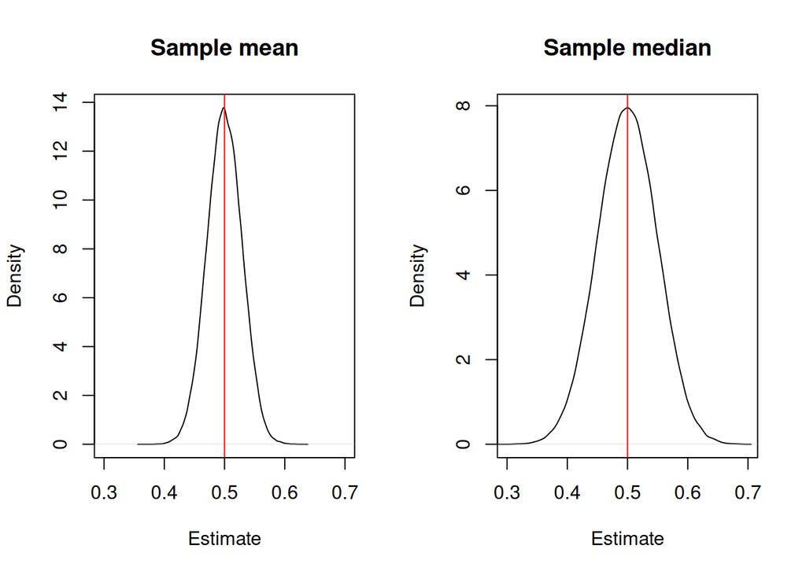

```r
# uniform(0,1), pop. mean and mediam are both 0.5
# setting a seed means that the code produces the same sequence so you can reproduce your results

set.seed(123)

#choose sample size and n of repetitions

n<- 100
B<- 100000

#numeric(B) creates a vector containing 100,000 zeros.
#These zeros are placeholders. During the simulation, we replace them with the mean and median calculated from each sample.

sample_means<- numeric(B)
sample_medians<- numeric(B)

#This starts a loop. R runs the instructions inside { ... } repeatedly:
#  - First, i = 1.
#- Then, i = 2.
#- It continues until i = 100000.

for (i in 1:B) {
  #runif() generates random observations from a uniform distribution.
  x<-runif(n,min=0,max=1)

  sample_means[i]<-mean(x)
  sample_medians[i]<- median(x)
}

#Once the loop finishes, you have 100,000 sample means and 100,000 sample medians, calculated from the same set of simulated samples.

# Plot the sampling distributions side by side
par(mfrow = c(1, 2))

plot(density(sample_means),
     main = "Sample mean", xlab = "Estimate",
     xlim = c(0.3, 0.7))
#density(sample mean) Estimates a smooth distribution curve from the simulated means
# plot draws curve, xlab sets titel, xlim limit hor axis

#add vertical line at center 0.5
abline(v = 0.5, col = "red")

#same for medians
plot(density(sample_medians),
     main = "Sample median", xlab = "Estimate",
     xlim = c(0.3, 0.7))
abline(v = 0.5, col = "red")
```

```r
#estimator whose results are more tightly concentrated around 0.5 has less sampling var, more accurate

par(mfrow = c(1, 1))

#calculate mse

mse_mean <- mean((sample_means - 0.5)^2)
mse_median <- mean((sample_medians - 0.5)^2)


# Display a formatted summary in the Console
#\n starts a new line.
#%.6f displays six decimal places.
#%-20s left-aligns text within a 20-character column.
#cat() prints without the [1] prefix.
#sprintf()lets you control decimal places and column alignment.

cat("\nEXERCISE 4.34 - SIMULATION RESULTS\n")
cat("----------------------------------------\n")
cat("Distribution: Uniform(0, 1)\n")
cat("Sample size:", n, "\n")
cat("Number of simulations:", B, "\n\n")

cat(sprintf("%-20s %12s\n", "Estimator", "MSE"))
cat(sprintf("%-20s %12.6f\n", "Sample mean", mse_mean))
cat(sprintf("%-20s %12.6f\n", "Sample median", mse_median))

cat(sprintf(
  "\nThe median's MSE is %.2f times the mean's MSE.\n",
  mse_median / mse_mean
))
```

```
##
## EXERCISE 4.34 - SIMULATION RESULTS
## ----------------------------------------
## Distribution: Uniform(0, 1)
## Sample size: 100
## Number of simulations: 1e+05
##
## Estimator                     MSE
## Sample mean              0.000834
## Sample median            0.002419
##
## The median's MSE is 2.90 times the mean's MSE.
```

## FSDS - Chapter 5

### Ex 5.8

*For the Students data file at the text website, analyze political ideology. (a) Test whether the population mean $\mu$ differs from 4.0, the moderate response. Report the P-value, and interpret. Make a conclusion using $\alpha$-level = 0.05. (b) Construct the 95% confidence interval for $\mu$. Explain how results relate to those of the test in (a).*

**Solution**

First we load the data and extract the variable of interest:

```r
Students <- read.table("http://stat4ds.rwth-aachen.de/data/Students.dat", header = TRUE)
y <- Students$ideol
```

Second we compute the sample size, the sample mean and the sample standard deviation:

$$\bar y = \frac{1}{n}\sum_{i=1}^n y_i, \qquad s = \sqrt{\frac{1}{n-1}\sum_{i=1}^n (y_i - \bar y)^2}$$

```r
n <- length(y)
ybar <- mean(y)
s <- sd(y)
c(n = n, ybar = ybar, s = s)
```

```
##         n      ybar         s
## 60.000000  3.033333  1.636104
```

**(a) Test whether $\mu$ differs from 4.0**

We assume $Y_i \sim \mathcal{N}(\mu, \sigma^2)$ i.i.d., with $\sigma^2$ unknown; the parameter of interest is the population mean ideology $\mu$. Since $n = 60$ is large, the t-test is reliable by the central limit theorem. "Differs from" gives no direction, so the alternative is two-sided:

$$H_0: \mu = 4 \qquad H_1: \mu \neq 4$$

Since $\sigma^2$ is unknown, we use the one-sample t-test statistic, which under $H_0$ follows a t distribution with $n - 1 = 59$ degrees of freedom:

$$T = \frac{\bar Y - \mu_0}{\sqrt{S^2/n}} \sim t_{n-1} = t_{59}$$

The standard error and the observed value of the test statistic are:

$$se = \frac{s}{\sqrt n} = \frac{1.636}{\sqrt{60}} = 0.211, \qquad t_{obs} = \frac{\bar y - \mu_0}{se} = \frac{3.033 - 4}{0.211} = -4.576$$

```r
mu0 <- 4
se <- s / sqrt(n)
t_obs <- (ybar - mu0) / se
c(se = se, t_obs = t_obs)
```

```
##         se      t_obs
##  0.2112201 -4.5765844
```

**(a) Report the P-value and interpret**

The alternative is two-sided, so we consider both tails; by the symmetry of the t distribution around 0:

$$p = \Pr_{H_0}(|T| \ge |t_{obs}|) = 2\{1 - F_{t_{59}}(|t_{obs}|)\}$$

```r
p_value <- 2 * (1 - pt(abs(t_obs), df = n - 1))
p_value
```

```
## [1] 2.48372e-05
```

Interpretation: if $\mu = 4$, the probability of a test statistic at least as extreme as $|t_{obs}| = 4.576$ is 0.0000248, so the observed data are very unlikely under $H_0$.

**(a) Conclusion using $\alpha = 0.05$**

With the significance level split in the two tails, the rejection region is:

$$R_\alpha = \{\, y : |T| \ge t_{n-1;\,1-\alpha/2} \,\}, \qquad t_{59;\,0.975} = 2.001$$

```r
qt(0.975, df = n - 1)
abs(t_obs) >= qt(0.975, df = n - 1)
p_value < 0.05
```

```
## [1] 2.000995
## [1] TRUE
## [1] TRUE
```

Since $|t_{obs}| = 4.576 \ge 2.001$ and $p = 0.0000248 < \alpha = 0.05$, we reject $H_0$ at the 5% level. The population mean political ideology differs from 4 (moderate); since $\bar y = 3.03 < 4$, it is below moderate.

Check: the same test in one command:

```r
t.test(y, mu = mu0)
```

```
##
##  One Sample t-test
##
## data:  y
## t = -4.5766, df = 59, p-value = 2.484e-05
## alternative hypothesis: true mean is not equal to 4
## 95 percent confidence interval:
##  2.610683 3.455984
## sample estimates:
## mean of x
##  3.033333
```

**(b) 95% confidence interval for $\mu$**

From the same pivot as the test, with 0.025 in each tail (equi-tailed interval):

$$\bar y \pm t_{n-1;\,0.975}\,\frac{s}{\sqrt n} = 3.033 \pm 2.001 \times 0.211 = 3.033 \pm 0.423 = (2.61,\ 3.46)$$

```r
me <- qt(0.975, df = n - 1) * se
ci95 <- ybar + c(-1, 1) * me
me
ci95
```

```
## [1] 0.4226505
## [1] 2.610683 3.455984
```

Interpretation: with 95% confidence, the population mean political ideology is between 2.61 and 3.46.

**(b) How the results relate to the test in (a)**

A two-sided test at level $\alpha$ rejects $H_0: \mu = \mu_0$ exactly when $\mu_0$ is outside the $(1-\alpha)$ confidence interval. Here $4 \notin (2.61,\ 3.46)$, which agrees with rejecting $H_0$ in (a).

### Ex 5.50

*A random sample of size 40 has $\bar y = 120$. The P-value for testing $H_0: \mu = 100$ against $H_a: \mu \neq 100$ is 0.057. Explain what is incorrect about each of the following interpretations of this P-value, and provide a proper interpretation. (a) The probability that $H_0$ is correct equals 0.057. (b) The probability that $\bar y = 120$ if $H_0$ is true equals 0.057. (c) The probability of Type I error equals 0.057. (d) We can accept $H_0$ at the $\alpha = 0.05$ level.*

**Solution**

Given: $n = 40$, $\bar y = 120$, $\mu_0 = 100$, $p = 0.057$. For a two-sided t-test with $n - 1 = 39$ degrees of freedom, the P-value is:

$$p = \Pr_{H_0}(|T| \ge |t_{obs}|) = 2\{1 - F_{t_{39}}(|t_{obs}|)\} = 0.057$$

that is, if $\mu = 100$, the probability of a sample mean $\bar y \ge 120$ or $\bar y \le 80$ is 0.057.

**(a) The probability that $H_0$ is correct equals 0.057**

Incorrect: the P-value is computed assuming $H_0$ is true, so it cannot be the probability that $H_0$ is true; $H_0$ is not a random event (it is either true or false).

**(b) The probability that $\bar y = 120$ if $H_0$ is true equals 0.057**

Incorrect: the P-value is the probability of values at least as extreme as the observed one, in both tails:

$$\Pr_{H_0}(\bar Y \ge 120 \ \text{or}\ \bar Y \le 80) = 0.057$$

not the probability of the single value $\bar y = 120$.

**(c) The probability of Type I error equals 0.057**

The probability of a Type I error is the significance level, fixed in advance:

$$\Pr(\text{Type I error}) = \Pr_{H_0}(\text{reject } H_0) = \alpha$$

Incorrect: the Type I error probability is $\alpha$, a property of the procedure, not the P-value of the observed data.

**(d) We can accept $H_0$ at the $\alpha = 0.05$ level**

Incorrect: $p = 0.057 > 0.05$ means we do not reject $H_0$, but this does not prove that $\mu = 100$: the data are only compatible with it. From the P-value we recover $|t_{obs}|$ and the standard error, and then the 95% confidence interval:

$$|t_{obs}| = t_{39;\,1-p/2}, \qquad se = \frac{\bar y - \mu_0}{|t_{obs}|}, \qquad \bar y \pm t_{39;\,0.975}\, se$$

```r
n <- 40
ybar <- 120
mu0 <- 100
p_value <- 0.057

t_abs <- qt(1 - p_value / 2, df = n - 1)
se <- (ybar - mu0) / t_abs
ci95 <- ybar + c(-1, 1) * qt(0.975, df = n - 1) * se
c(t_abs = t_abs, se = se)
ci95
```

```
##     t_abs        se
##  1.961397 10.196815
## [1]  99.375 140.625
```

100 is inside the 95% confidence interval, but so are all values up to about 140.6.

**Proper interpretation**

If $\mu = 100$, a sample mean as far from 100 as 120 (or farther, in either direction) would occur with probability 0.057. Since $p = 0.057 > 0.05$, we do not reject $H_0$ at $\alpha = 0.05$.

### Ex 5.58

*A researcher conducts a significance test every time she analyzes a new data set. Over time, she conducts 100 significance tests, each at the 0.05 level. If $H_0$ is true in every case, what is the probability distribution of the number of times she rejects $H_0$, and how many times would we expect $H_0$ to be rejected?*

**Solution**

**Probability distribution of the number of rejections**

Since $H_0$ is true, rejecting it is a Type I error, so in each test:

$$\Pr_{H_0}(\text{reject } H_0) = \alpha = 0.05$$

Each test is a Bernoulli trial (reject / not reject) with probability 0.05, and the 100 tests are independent (a new data set each time). Therefore the number of rejections $X$ follows a binomial distribution:

$$X \sim \text{Bin}(n = 100,\ \pi = 0.05), \qquad \Pr(X = x) = \binom{100}{x} 0.05^x\, 0.95^{100 - x}, \quad x = 0, 1, \dots, 100$$

```r
n_tests <- 100
alpha <- 0.05
round(dbinom(0:10, size = n_tests, prob = alpha), 4)
```

```
##  [1] 0.0059 0.0312 0.0812 0.1396 0.1781 0.1800 0.1500 0.1060 0.0649 0.0349
## [11] 0.0167
```

**Expected number of rejections**

$$E(X) = n\pi = 100 \times 0.05 = 5$$

```r
n_tests * alpha
```

```
## [1] 5
```

Conclusion: $X \sim \text{Bin}(100, 0.05)$, and we expect $H_0$ to be rejected about 5 times, all of them Type I errors, even though $H_0$ is true in every case.